# Компьютерная работа №2

2023-04-29

```r
data <- read.csv("USA_Housing.csv", stringsAsFactors = TRUE)
```

```r
str(data)
```

```
## 'data.frame':    5000 obs. of  7 variables:
##  $ Avg..Area.Income            : num  79545 79249 61287 63345 59982 ...
##  $ Avg..Area.House.Age         : num  5.68 6 5.87 7.19 5.04 ...
##  $ Avg..Area.Number.of.Rooms   : num  7.01 6.73 8.51 5.59 7.84 ...
##  $ Avg..Area.Number.of.Bedrooms: num  4.09 3.09 5.13 3.26 4.23 4.04 3.41 2.42 2.3 6.1 ...
##  $ Area.Population             : num  23087 40173 36882 34310 26354 ...
##  $ Price                       : num  1059034 1505891 1058988 1260617 630943 ...
##  $ Address                     : Factor w/ 5000 levels "000 Adkins Crescent\nSouth Teresa, AS 49642-1348",..: 963 864 4070 4957 4899 312 2148 4345 4969 4806 ...
```

```r
newdf <- subset(data, select = -c(7))
```

Перед компонентным анализом к исследуемому набору данных необходимо применить стандартизацию, тк мы хотим соотнести переменные, когда их средние значения и стандартные отклонения сильно разнятся.

```r
data_scaled <- scale(newdf)
data_scaled <- data.frame(data_scaled)
str(data_scaled)
```

```
## 'data.frame':    5000 obs. of  6 variables:
##  $ Avg..Area.Income            : num  1.029 1.001 -0.685 -0.491 -0.807 ...
##  $ Avg..Area.House.Age         : num  -0.2969 0.0259 -0.1123 1.2214 -0.9447 ...
##  $ Avg..Area.Number.of.Rooms   : num  0.0213 -0.2555 1.5161 -1.3929 0.8467 ...
##  $ Avg..Area.Number.of.Bedrooms: num  0.0881 -0.7222 0.9307 -0.5845 0.2015 ...
##  $ Area.Population             : num  -1.3175 0.404 0.0724 -0.1867 -0.9883 ...
##  $ Price                       : num  -0.49 0.7754 -0.4902 0.0808 -1.7023 ...
```

Предварительный визуальный анализ распределений:

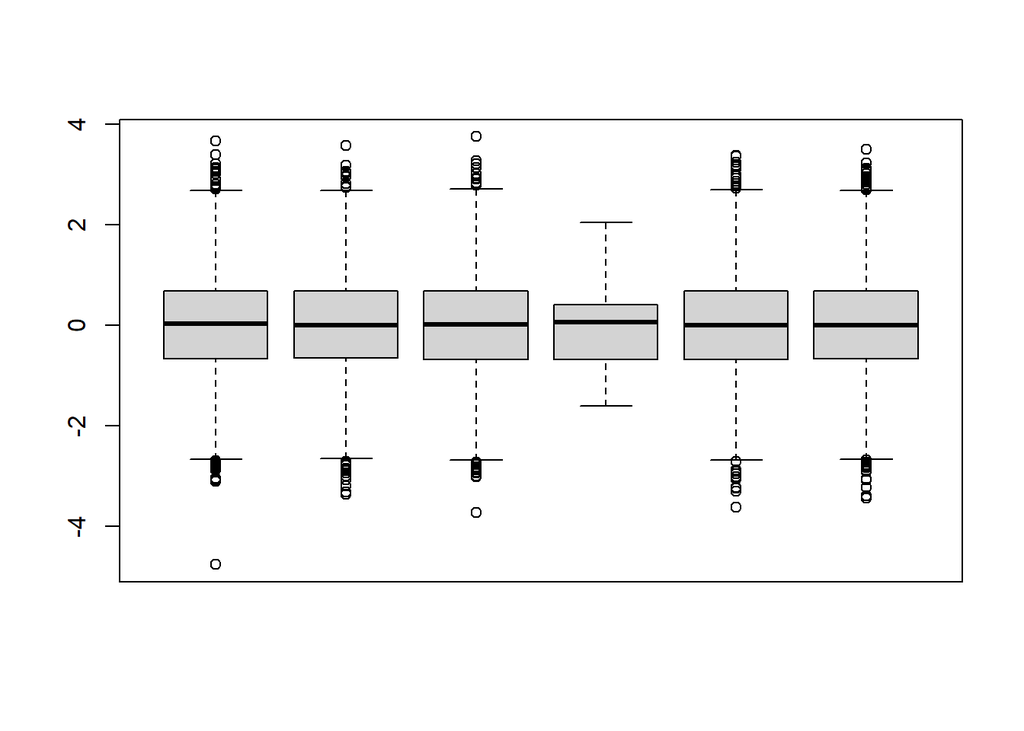

```r
boxplot(data_scaled, xaxt = "n", cex.lab = 0.7)
```

- Снижение размерности будет достигаться, если признаки, описывающие совокупность, достаточно коррелированы между собой. В данном случае разумно объединить переменные, отражающие кол-во комнат.
- Объединять остальные признаки в одну компоненту, вероятно, некорректно ввиду отсутствия коррелиции.

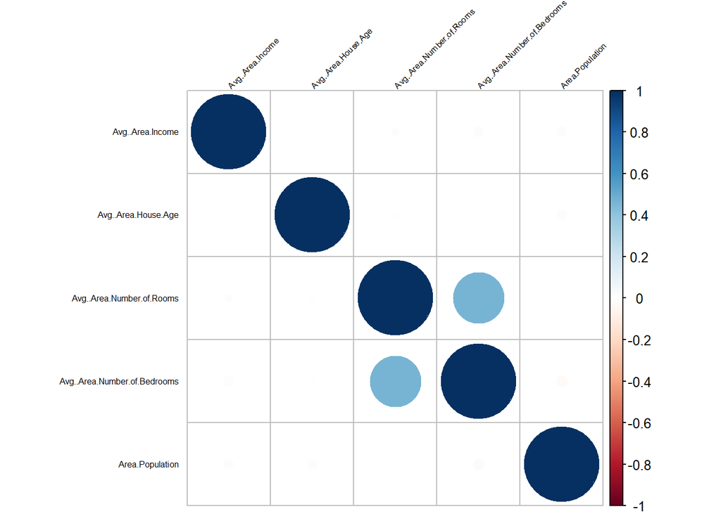

```r
indep_data <- data_scaled[1:5]
corrplot(cor(indep_data), type = "full", method = "circle", tl.col = "black", tl.srt = 45, tl.cex = 0.5)
```

Применим тест сферичности Бартлетта, который используется для оценки эффективности методов снижения размерности. Данный тест проверяет нулевую гипотезу о том, что теоретическая корреляционная матрица многомерного распределения вектора случайных величин, является единичной матрицей. Если нулевая гипотеза отвергается, предпосылки применения метода главных компонента будут выполнены.

```r
bart_spher(indep_data)
```

```
##  Bartlett's Test of Sphericity
##
## Call: bart_spher(x = indep_data)
##
##      X2 = 1215.746
##      df = 10
## p-value < 2.22e-16
```

- Значение p-value проведенного теста меньше уровня значимости 5%. Нулевая гипотеза отвергается, применение МГК обосновано.

Для построения главных компонент будем использовать только непрерывные независимые переменные:

```r
indep_data <- data_scaled[1:5]
str(indep_data)
```

```
## 'data.frame':    5000 obs. of  5 variables:
##  $ Avg..Area.Income            : num  1.029 1.001 -0.685 -0.491 -0.807 ...
##  $ Avg..Area.House.Age         : num  -0.2969 0.0259 -0.1123 1.2214 -0.9447 ...
##  $ Avg..Area.Number.of.Rooms   : num  0.0213 -0.2555 1.5161 -1.3929 0.8467 ...
##  $ Avg..Area.Number.of.Bedrooms: num  0.0881 -0.7222 0.9307 -0.5845 0.2015 ...
##  $ Area.Population             : num  -1.3175 0.404 0.0724 -0.1867 -0.9883 ...
```

Далее приступаем непосредственно к анализу методом главных компонент:

```r
res.pca <- PCA(indep_data,graph=FALSE)
```

## Выделение главных компонент

### 1. Число главных компонент:

Находим собственные значения:

```r
eig <- res.pca$eig
eig
```

```
##        eigenvalue percentage of variance cumulative percentage of variance
## comp 1  1.4632363               29.26473                          29.26473
## comp 2  1.0251136               20.50227                          49.76700
## comp 3  1.0020857               20.04171                          69.80871
## comp 4  0.9740941               19.48188                          89.29059
## comp 5  0.5354703               10.70941                         100.00000
```

1. Критерий Кайзера: Выбираем количество компонент, когда eigenvalue > 1. В нашем случае получаем три новые компоненты.

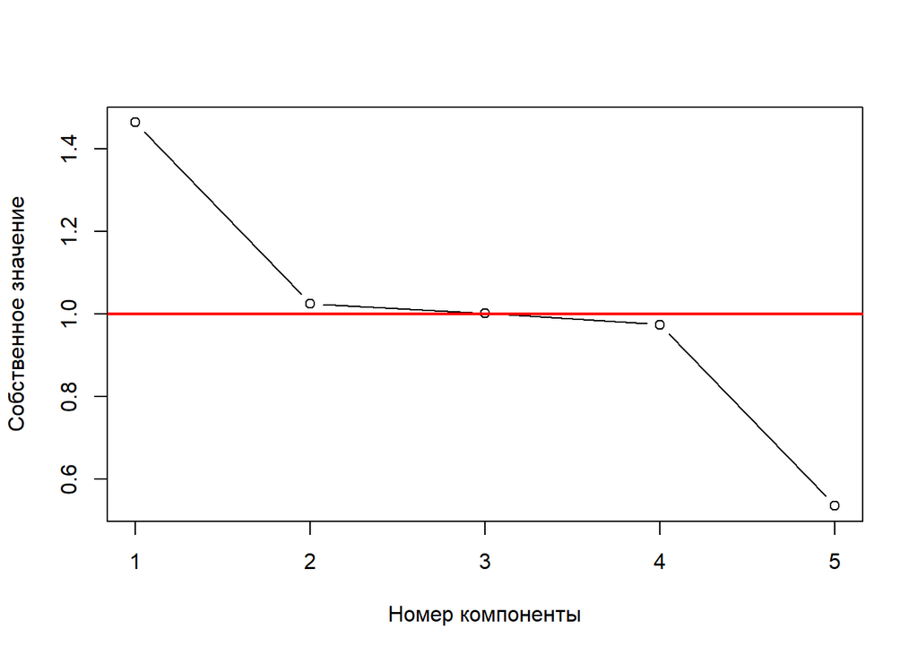

```r
plot(eigen(cor(indep_data))$values, bstick = TRUE, type = 'b', main = '', xlab = 'Номер компоненты',
     ylab = 'Собственное значение')
abline(h = 1, col = 'red', lwd = 2)
text(x = 13, y = 1.2, 'eigen value = 1', col = 'red')
```

(б) Доли суммарной вариации. Оптимальное число определяется в соответствии с долей суммарной вариации исходных признаков, которую требуется сохранить (обычно 70-80%).

```r
princomp <- princomp(indep_data, cor = TRUE)
summary(princomp)
```

```
## Importance of components:
##                           Comp.1    Comp.2    Comp.3    Comp.4    Comp.5
## Standard deviation     1.2096430 1.0124789 1.0010423 0.9869621 0.7317584
## Proportion of Variance 0.2926473 0.2050227 0.2004171 0.1948188 0.1070941
## Cumulative Proportion  0.2926473 0.4976700 0.6980871 0.8929059 1.0000000
```

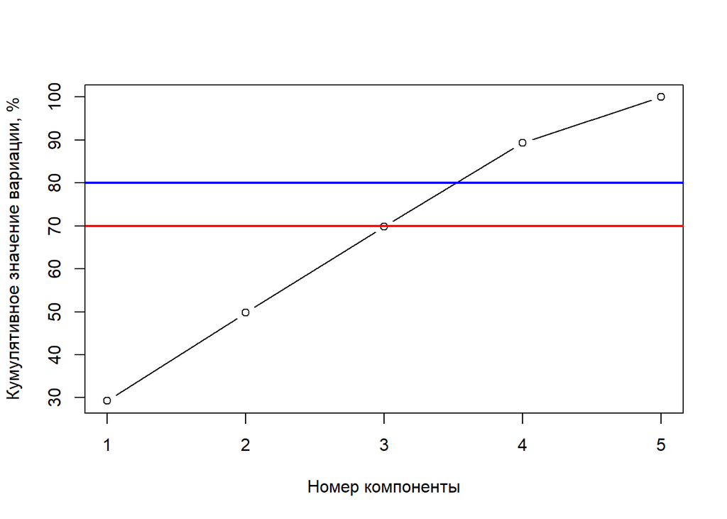

```r
cumvarsum <- cumsum(princomp$sdev^2 / sum(princomp$sdev^2))*100
plot(cumvarsum, bstick = TRUE, type = 'b', main = '', xlab = 'Номер компоненты',
     ylab = 'Кумулятивное значение вариации, %')
abline(h = 70, col = 'red', lwd = 2)
abline(h = 80, col = 'blue', lwd = 2)
text(x = 13, y = 75, '70%', col = 'red')
text(x = 13, y = 85, '80%', col = 'blue')
```

- Оптимальное число ГК - три.

(в) Критерий каменистой осыпи: сложно выделить точку, где убывание собственных значений замедляется наиболее сильно. В целом, оптимальное значение компонент - три или четыре.

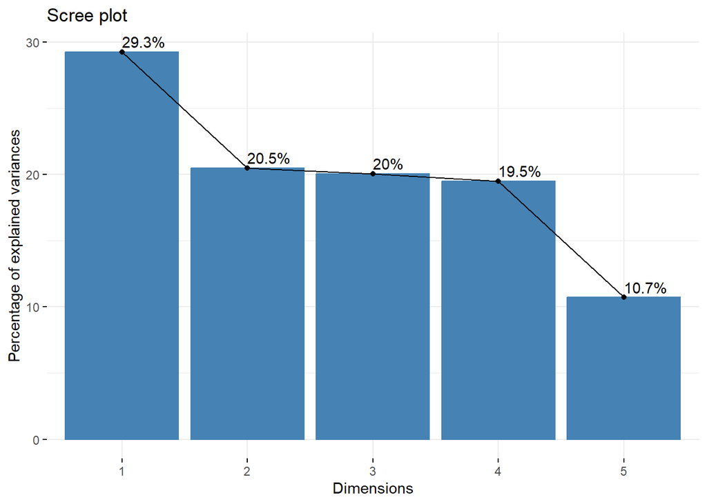

```r
fviz_eig(res.pca, addlabels = TRUE)
```

Убедимся, что главные компоненты линейно независимы:

```r
cor.test(princomp$scores[,1], princomp$scores[,2])
```

```
##
##  Pearson's product-moment correlation
##
## data:  princomp$scores[, 1] and princomp$scores[, 2]
## t = 7.2496e-15, df = 4998, p-value = 1
## alternative hypothesis: true correlation is not equal to 0
## 95 percent confidence interval:
##  -0.02771929  0.02771929
## sample estimates:
##          cor
## 1.025447e-16
```

```r
cor.test(princomp$scores[,1], princomp$scores[,3])
```

```
##
##  Pearson's product-moment correlation
##
## data:  princomp$scores[, 1] and princomp$scores[, 3]
## t = 6.8623e-15, df = 4998, p-value = 1
## alternative hypothesis: true correlation is not equal to 0
## 95 percent confidence interval:
##  -0.02771929  0.02771929
## sample estimates:
##          cor
## 9.706652e-17
```

### 2. Суммарный вклад главных компонент:

Cumulative percentage of variance согласно таблице, указанной выше, для первых трех ГК равен 69,8%, для четырех - 89,2%.

### 3. Построение графика накопленного вклада ГК:

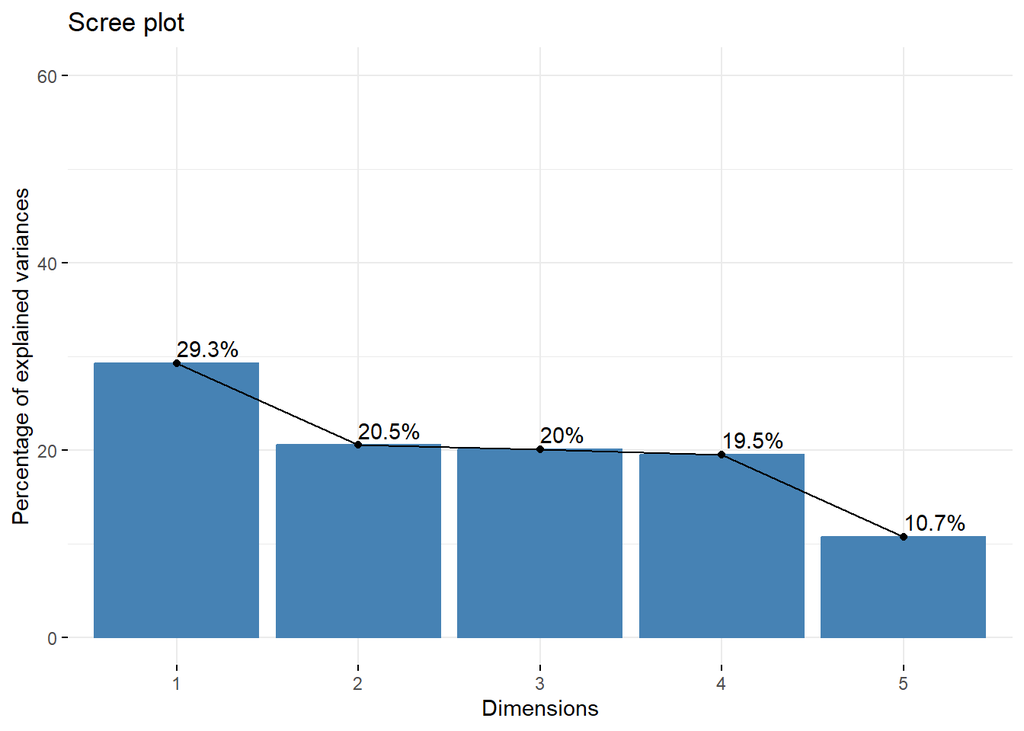

```r
fviz_eig(res.pca, addlabels = TRUE, ylim = c(0, 60))
```

- В целом, видно, что накопленная вариация растет на 20%, начиная со 2 по 4 компоненту, вероятно, стоит выделить все-таки 4 компоненты.

### 4. Интерпретация ГК на основе матрицы факторных нагрузок

В итоге предполагается 4 сферы влияния на зависимую переменную. Отобразим матрицу факторных нагрузок:

```r
pca <- principal(cor(indep_data), nfactors = 4, rotate = "none", covar = FALSE)

pca_loadings <- matrix(as.numeric(pca$loadings), ncol = 4, nrow = ncol(indep_data))
rownames(pca_loadings) <- colnames(indep_data)

kbl(round(pca_loadings, 4),
    caption = "Таблица 1. Матрица факторных нагрузок",
    booktabs = T, col.names = c("PC1", "PC2", "PC3", "PC4")) %>%
    kable_classic(html_font = "Cambria", font_size = 12, full_width = F)
```

Таблица 1. Матрица факторных нагрузок

|  | PC1 | PC2 | PC3 | PC4 |
| --- | --- | --- | --- | --- |
| Avg..Area.Income | 0.0175 | 0.4682 | 0.7523 | 0.4619 |
| Avg..Area.House.Age | -0.0046 | 0.5295 | -0.6599 | 0.5327 |
| Avg..Area.Number.of.Rooms | 0.8541 | -0.0605 | -0.0231 | 0.0052 |
| Avg..Area.Number.of.Bedrooms | 0.8556 | 0.0219 | 0.0044 | 0.0185 |
| Area.Population | -0.0376 | -0.7221 | 0.0059 | 0.6903 |

Первая компонента учитывает размера квартиры. У нагрузок Num of Rooms & Bedroom положительный знак, то есть чем больше комнат в квартире, тем больше размер.

На наш взгляд, объединять переменные (кроме кол-ва комнат) в одну компонену некорректно, поскольку все они несут разный экономический смысл.

Таким образом, выделено 4 главные компонены.

# Построение уравнения регрессии с использованием выделенных ГК

В прошлом пункте мы опрелелили, что оптимальными компонентами будут первые 4 переменные.

```r
pc <- as.data.frame(res.pca$ind$coord)
pc1 <- pc$Dim.1
pc2 <- pc$Dim.2
pc3 <- pc$Dim.3
pc4 <- pc$Dim.4
pander(summary(lm(newdf$Price ~ pc1 + pc2 + pc3 + pc4)))
```

|  | Estimate | Std. Error | t value | Pr(>\|t\|) |
| --- | --- | --- | --- | --- |
| **(Intercept)** | 1232073 | 1725 | 714.1 | 0 |
| **pc1** | 85147 | 1426 | 59.7 | 0 |
| **pc2** | 77428 | 1704 | 45.44 | 0 |
| **pc3** | 62670 | 1724 | 36.36 | 4.725e-257 |
| **pc4** | 302454 | 1748 | 173 | 0 |

Fitting linear model: newdf$Price ~ pc1 + pc2 + pc3 + pc4

| Observations | Residual Std. Error | $R^2$ | Adjusted $R^2$ |
| --- | --- | --- | --- |
| 5000 | 121997 | 0.8807 | 0.8806 |

Данная модель имеет большой коэффициент $R^2$, что говорит о том, что главные компоненты выбраны правильно

```r
lmGK <- lm(newdf$Price ~ Comp.1 + Comp.2 + Comp.3 + Comp.4, data.frame(princomp$scores))
pander(summary(lmGK))
```

|  | Estimate | Std. Error | t value | Pr(>\|t\|) |
| --- | --- | --- | --- | --- |
| **(Intercept)** | 1232073 | 1725 | 714.1 | 0 |
| **Comp.1** | 85147 | 1426 | 59.7 | 0 |
| **Comp.2** | 77428 | 1704 | 45.44 | 0 |
| **Comp.3** | 62670 | 1724 | 36.36 | 4.725e-257 |
| **Comp.4** | 302454 | 1748 | 173 | 0 |

Fitting linear model: newdf$Price ~ Comp.1 + Comp.2 + Comp.3 + Comp.4

| Observations | Residual Std. Error | $R^2$ | Adjusted $R^2$ |
| --- | --- | --- | --- |
| 5000 | 121997 | 0.8807 | 0.8806 |

Данная модель имеет большой коэффициент $R^2$, что говорит о том, что главные компоненты выбраны правильно, так же все коэффициенты значимые.

Далее построим уравнение регресcии на все переменные

```r
pander(summary(lm(newdf$Price ~ ., newdf)))
```

|  | Estimate | Std. Error | t value | Pr(>\|t\|) |
| --- | --- | --- | --- | --- |
| **(Intercept)** | -2637299 | 17158 | -153.7 | 0 |
| **Avg..Area.Income** | 21.58 | 0.1343 | 160.7 | 0 |
| **Avg..Area.House.Age** | 165637 | 1443 | 114.8 | 0 |
| **Avg..Area.Number.of.Rooms** | 120660 | 1605 | 75.17 | 0 |
| **Avg..Area.Number.of.Bedrooms** | 1651 | 1309 | 1.262 | 0.2071 |
| **Area.Population** | 15.2 | 0.1442 | 105.4 | 0 |

Fitting linear model: newdf$Price ~ .

| Observations | Residual Std. Error | $R^2$ | Adjusted $R^2$ |
| --- | --- | --- | --- |
| 5000 | 101153 | 0.918 | 0.9179 |

Как мы видим, в данной модели все переменные являются значимыми за исключением переменной Avg..Area.Number.of.Bedrooms, удалим ее.

```r
lmvse <- lm(newdf$Price ~ Avg..Area.Income + Avg..Area.House.Age + Avg..Area.Number.of.Rooms + Area.Population, newdf)
pander(summary(lmvse))
```

|  | Estimate | Std. Error | t value | Pr(>\|t\|) |
| --- | --- | --- | --- | --- |
| **(Intercept)** | -2637561 | 17158 | -153.7 | 0 |
| **Avg..Area.Income** | 21.58 | 0.1343 | 160.7 | 0 |
| **Avg..Area.House.Age** | 165658 | 1443 | 114.8 | 0 |
| **Avg..Area.Number.of.Rooms** | 121598 | 1423 | 85.48 | 0 |
| **Area.Population** | 15.2 | 0.1442 | 105.4 | 0 |

Fitting linear model: newdf$Price ~ Avg..Area.Income + Avg..Area.House.Age + Avg..Area.Number.of.Rooms + Area.Population

| Observations | Residual Std. Error | $R^2$ | Adjusted $R^2$ |
| --- | --- | --- | --- |
| 5000 | 101159 | 0.918 | 0.9179 |

Как мы видим, $R^2$ в данном случае больше, нежели в случае с главными компонентами.

Построим регрессию на логарифмированные данные, то есть возьмем нелинейную модель

```r
ldf <- log(newdf)
lmlog <- lm(Price ~ Avg..Area.Income + Avg..Area.House.Age + Avg..Area.Number.of.Rooms + Avg..Area.Number.of.Bedrooms + Area.Population, ldf)
pander(summary(lmlog))
```

|  | Estimate | Std. Error | t value | Pr(>\|t\|) |
| --- | --- | --- | --- | --- |
| **(Intercept)** | -8.012 | 0.1521 | -52.68 | 0 |
| **Avg..Area.Income** | 1.306 | 0.01191 | 109.6 | 0 |
| **Avg..Area.House.Age** | 0.8744 | 0.01116 | 78.34 | 0 |
| **Avg..Area.Number.of.Rooms** | 0.7493 | 0.01454 | 51.55 | 0 |
| **Avg..Area.Number.of.Bedrooms** | 0.005059 | 0.006769 | 0.7473 | 0.4549 |
| **Area.Population** | 0.4263 | 0.00608 | 70.12 | 0 |

Fitting linear model: Price ~ Avg..Area.Income + Avg..Area.House.Age + Avg..Area.Number.of.Rooms + Avg..Area.Number.of.Bedrooms + Area.Population

| Observations | Residual Std. Error | $R^2$ | Adjusted $R^2$ |
| --- | --- | --- | --- |
| 5000 | 0.1358 | 0.8374 | 0.8372 |

`Avg..Area.Number.of.Bedrooms` снова оказался незначимым, и не забываем про корреляцию с `Avg..Area.Number.of.Rooms`. Удаляем эту переменную и строим новую модель.

```r
lmlog2 <- lm(Price ~ Avg..Area.Income + Avg..Area.House.Age + Avg..Area.Number.of.Rooms + Area.Population, ldf)
pander(summary(lmlog2))
```

|  | Estimate | Std. Error | t value | Pr(>\|t\|) |
| --- | --- | --- | --- | --- |
| **(Intercept)** | -8.017 | 0.1519 | -52.77 | 0 |
| **Avg..Area.Income** | 1.306 | 0.01191 | 109.7 | 0 |
| **Avg..Area.House.Age** | 0.8745 | 0.01116 | 78.36 | 0 |
| **Avg..Area.Number.of.Rooms** | 0.7542 | 0.01295 | 58.24 | 0 |
| **Area.Population** | 0.4263 | 0.006079 | 70.12 | 0 |

Fitting linear model: Price ~ Avg..Area.Income + Avg..Area.House.Age + Avg..Area.Number.of.Rooms + Area.Population

| Observations | Residual Std. Error | $R^2$ | Adjusted $R^2$ |
| --- | --- | --- | --- |
| 5000 | 0.1358 | 0.8374 | 0.8373 |

Проведем тесты на нормальность для всех трех уравнений

Тесты на нормальность для модел главных компонент

```r
PearsonTest(lmGK$residuals)
```

```
##
##  Pearson chi-square normality test
##
## data:  lmGK$residuals
## P = 59.12, p-value = 0.4344
```

```r
shapiro.test(lmGK$residuals)
```

```
##
##  Shapiro-Wilk normality test
##
## data:  lmGK$residuals
## W = 0.99934, p-value = 0.06209
```

В данном случае гипотеза о нормальности распределения не отвергается, следовательно модель главных компонент можно использовать на наших данных.

Тесты на нормальность для линейной регрессионной модели

```r
PearsonTest(lmvse$residuals)
```

```
##
##  Pearson chi-square normality test
##
## data:  lmvse$residuals
## P = 56.363, p-value = 0.5364
```

```r
shapiro.test(lmvse$residuals)
```

```
##
##  Shapiro-Wilk normality test
##
## data:  lmvse$residuals
## W = 0.99957, p-value = 0.341
```

В обоих случаях тесты не отвергают гипотезу о нормальном распределении

Тесты на нормальность для нелинейной модели

```r
shapiro.test(lmlog2$residuals)
```

```
##
##  Shapiro-Wilk normality test
##
## data:  lmlog2$residuals
## W = 0.79255, p-value < 2.2e-16
```

```r
PearsonTest(lmlog2$residuals)
```

```
##
##  Pearson chi-square normality test
##
## data:  lmlog2$residuals
## P = 608.11, p-value < 2.2e-16
```

В данном случае оба тест отвргают гипотезу о подчинении данной модели нормальному закону распределения, следовательно нам нужно будет выбрать из двух моделей, модели построенной на основе главных компонент и на линейной модели.

В модели, построенной на основе главных компонент AdjustetR^2 равен 0.8806, в случае с линенйной регрессии это значение равно 0.9179, про этому показателю линейная модель будет предпочтительней

Так же проведем сравнение уравнений регрессий с помощью критерия Акаике и Шварца

```r
IC_table <- data.frame(n = c('lmGK', 'lmvse'),
                  a = rbind(AIC(lmGK), AIC(lmvse)),
                  b = rbind(BIC(lmGK), BIC(lmvse)))
# информационный критерий Акаике
kbl(IC_table,
    caption = "Таблица 1. Информационные критерии Акаике и Шварца (Баесовский инф. критерий)",
    booktabs = T, col.names = c("Модель", "Значение AIC", "Значение BIC")) %>%
    kable_classic(html_font = "Cambria", font_size = 12, full_width = F)
```

Таблица 1. Информационные критерии Акаике и Шварца (Баесовский инф. критерий)

| Модель | Значение AIC | Значение BIC |
| --- | --- | --- |
| lmGK | 131313.9 | 131353 |
| lmvse | 129440.9 | 129480 |

Как мы видим, значения по двум критериям меньше у линейной регрессионной модели, построенной по всем данным, за исключением AVG.Numbers.Of.Bedrooms, следовательно самым предпочтительным вариантом будет использование модели $lmvse$

#Кластерный анализ

## Cейчас следует провести отбор классифицирующих признаков:

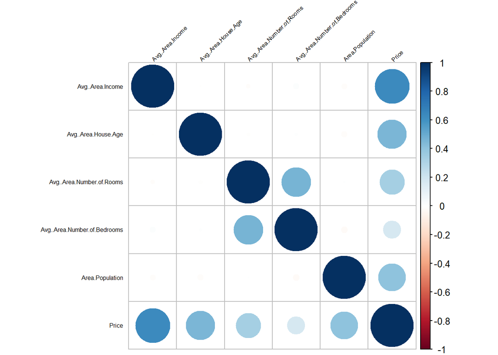

```r
corrplot(cor(scale(df6)), type = "full", method = "circle", tl.col = "black", tl.srt = 45, tl.cex = 0.5)
```

```r
df1 <- df[, -c(6)]
str(df1)
```

```
## 'data.frame':    5000 obs. of  5 variables:
##  $ Avg..Area.Income            : num  79545 79249 61287 63345 59982 ...
##  $ Avg..Area.House.Age         : num  5.68 6 5.87 7.19 5.04 ...
##  $ Avg..Area.Number.of.Rooms   : num  7.01 6.73 8.51 5.59 7.84 ...
##  $ Avg..Area.Number.of.Bedrooms: num  4.09 3.09 5.13 3.26 4.23 4.04 3.41 2.42 2.3 6.1 ...
##  $ Area.Population             : num  23087 40173 36882 34310 26354 ...
```

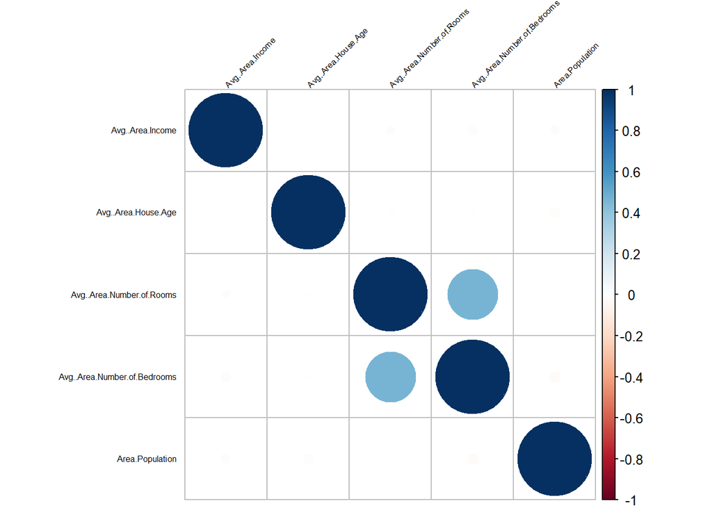

```r
corrplot(cor(scale(df1)), type = "full", method = "circle", tl.col = "black", tl.srt = 45, tl.cex = 0.5)
```

*Теперь cильной корреляции нет*

## Cейчас выберем оптимальное количество кластеров:

```r
cluster_df <- as.data.frame(scale(df6))
```

Воспользуемся методом силуетов:

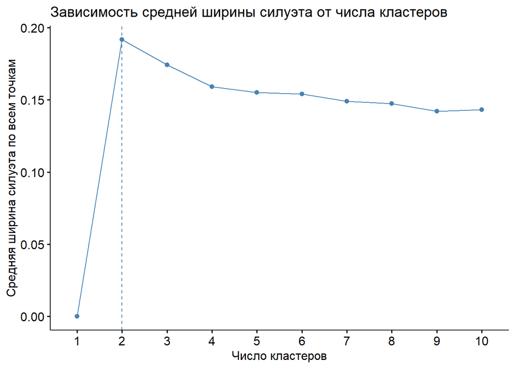

```r
fviz_nbclust(cluster_df, kmeans, method = 'silhouette') +
  labs(x = 'Число кластеров', y = 'Средняя ширина силуэта по всем точкам',
       title = 'Зависимость средней ширины силуэта от числа кластеров')
```

*Как мы можем заметить 2 явяется оптимальным числом кластеров для наших данных*

Также воспользуемся методом локтя:

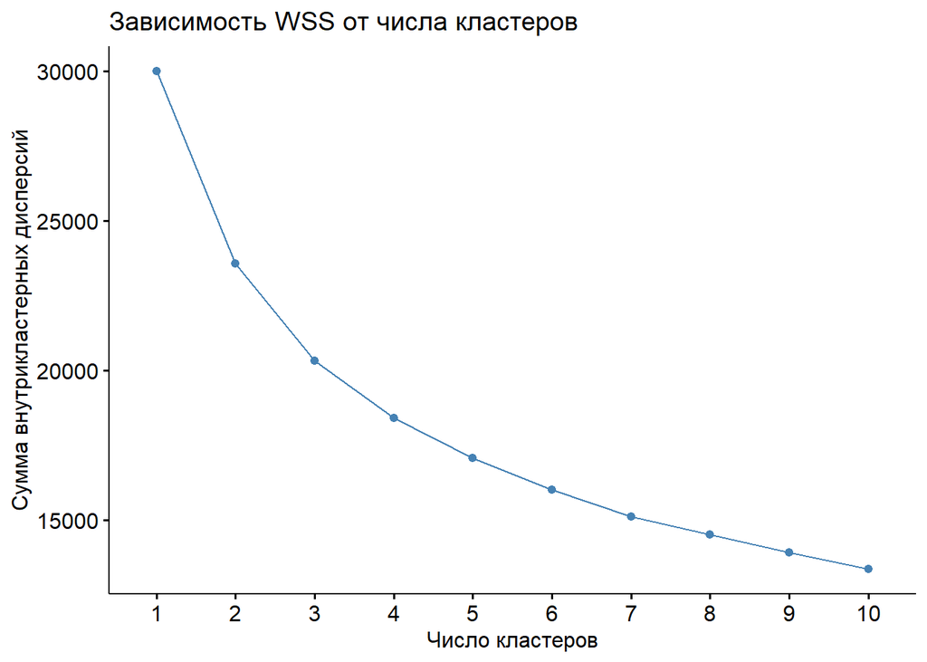

```r
fviz_nbclust(cluster_df, kmeans, method = 'wss') +
  labs(x = 'Число кластеров', y = 'Сумма внутрикластерных дисперсий',
       title = 'Зависимость WSS от числа кластеров')
```

*На данной диаграмме мы можем заметить замедление после достижения 2го кластера, что также говорит нам о том, что оптимальным является 2 кластера*

Воспользуемся 3 методом - статистикой разрыва:

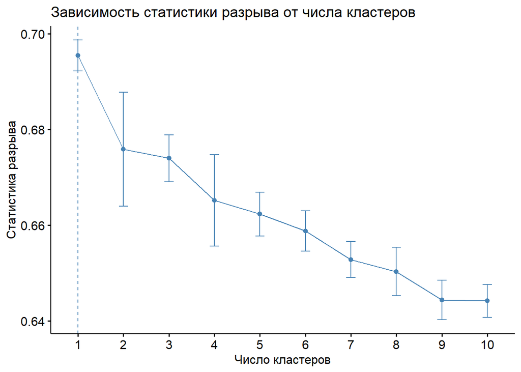

```r
fviz_nbclust(cluster_df, kmeans, method = 'gap_stat') +
  labs(x = 'Число кластеров', y = 'Статистика разрыва',
       title = 'Зависимость статистики разрыва от числа кластеров')
```

*При сравнительном анализе последовательности значений, наибольшее значение статистики соответствует наиболее полезной группировке, дисперсия которой максимально меньше внутригрупповой дисперсии кластеров, собранных из случайных объектов исходной выборки: у нас показывает, что кластер должен быть 1, но поскольку два других метода показали нам, что кластеров должно быть 2, и разница внутригрупповой дисперсии кластеров между 1 и 2 небольшая, мы определим, что оптимальное количество кластеров - 2.*

## Рассмотрим различные принципы определения расстояния между кластерами

Поскольку ранее мы определили оптимальное количество кластеров, будем использовать именно его (k=2)

# Метод Варда:

```r
set.seed(1337)
s <- as.data.frame(sample(seq_len(nrow(cluster_df)), size = 1000))
hclust_ward <- hcut(s, k = 2, hc_metric = 'euclidian', hc_method = 'ward.D2')
```

Изобразим результаты с помощью дендрограммы:

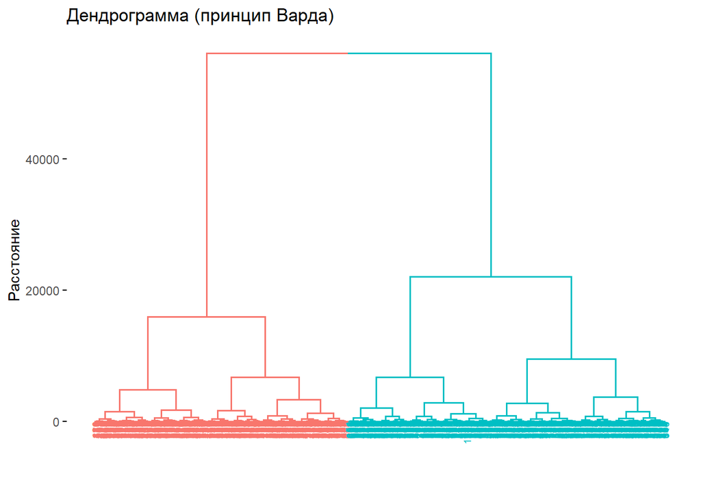

```r
fviz_dend(hclust_ward,
          cex = 0.5,
          color_labels_by_k = TRUE,
          main = 'Дендрограмма (принцип Варда)', ylab = 'Расстояние')
```

*Разбиение по методу Варда дает достаточно хорошие и интерпретабельные разультаты*

# Метод ближнего соседа:

```r
set.seed(1337)
s <- as.data.frame(sample(seq_len(nrow(cluster_df)), size = 1000))
hclust_nn <- hcut(s, k = 2, hc_metric = 'euclidian', hc_method = 'single')
```

Изобразим результаты с помощью дендрограммы:

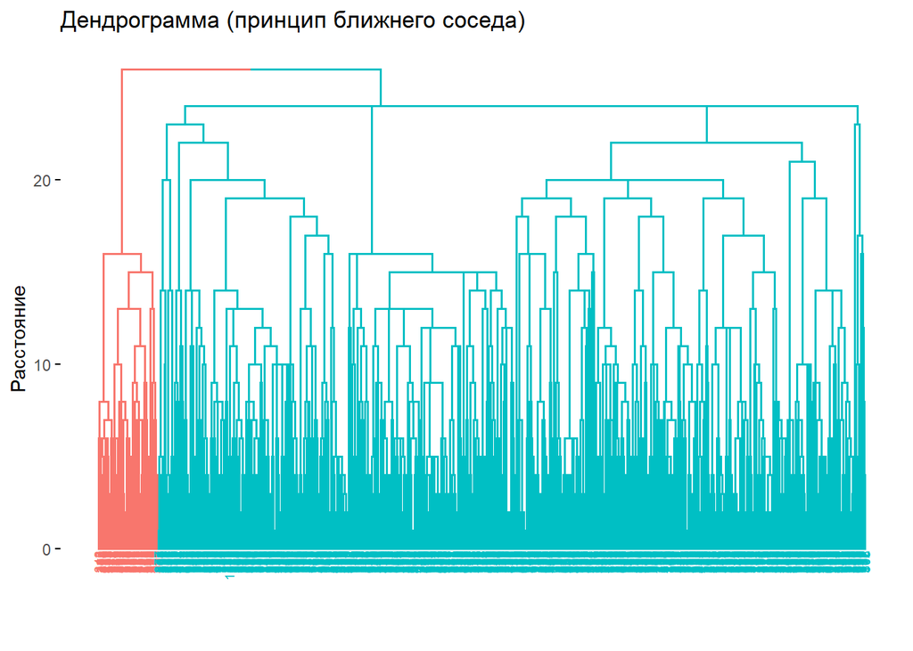

```r
fviz_dend(hclust_nn,
          cex = 0.5,
          color_labels_by_k = TRUE,
          main = 'Дендрограмма (принцип ближнего соседа)', ylab = 'Расстояние')
```

# Метод дальнего соседа:

```r
set.seed(1337)
s <- as.data.frame(sample(seq_len(nrow(cluster_df)), size = 1000))
hclust_lg <- hcut(s, k = 2, hc_metric = 'euclidian', hc_method = 'complete')
```

Изобразим результаты с помощью дендрограммы:

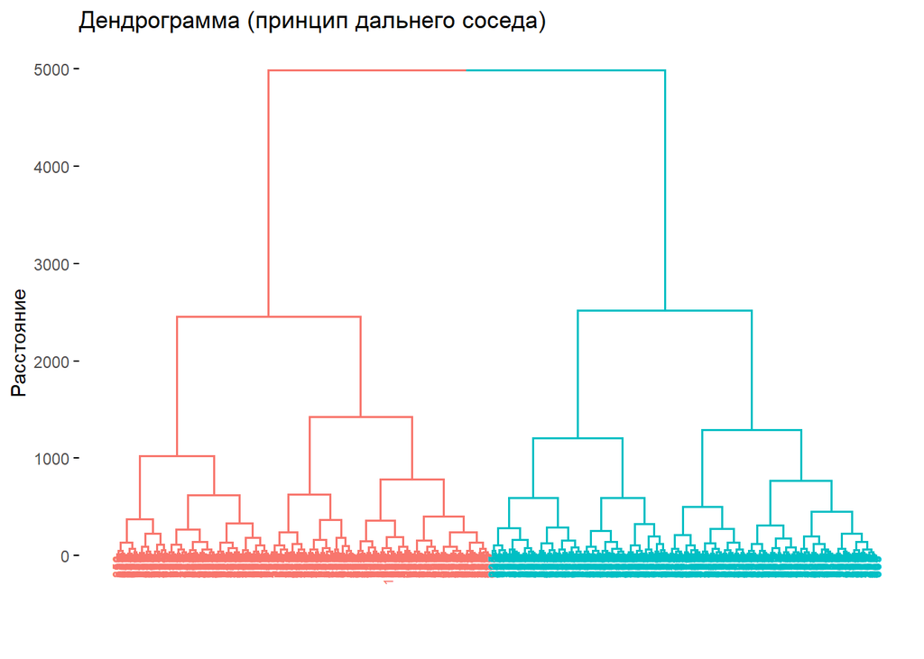

```r
fviz_dend(hclust_lg,
          cex = 0.5,
          color_labels_by_k = TRUE,
          main = 'Дендрограмма (принцип дальнего соседа)', ylab = 'Расстояние')
```

# Метод средней связи:

```r
set.seed(1337)
s <- as.data.frame(sample(seq_len(nrow(cluster_df)), size = 1000))
hclust_av <- hcut(s, k = 2, hc_metric = 'euclidian', hc_method = 'average')
```

Изобразим результаты с помощью дендрограммы:

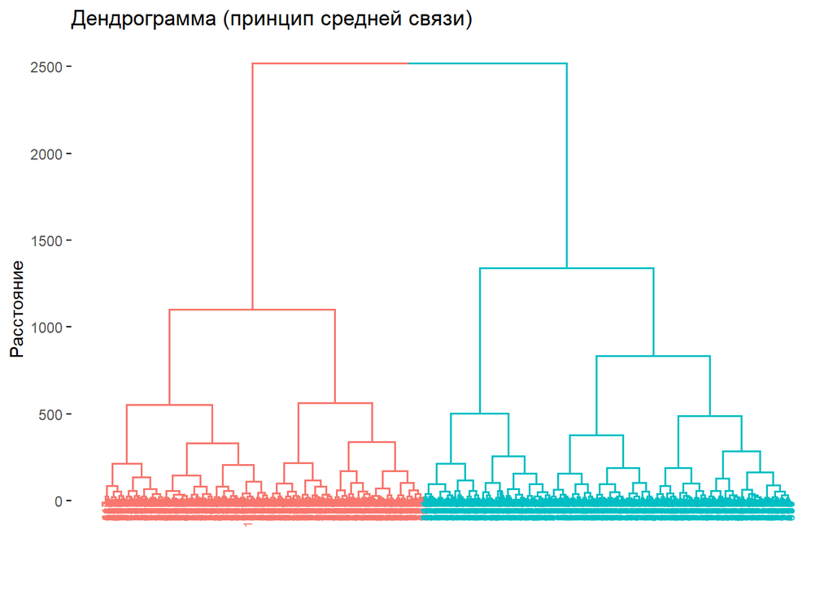

```r
fviz_dend(hclust_av, cex = 0.5, color_labels_by_k = TRUE,
          main = 'Дендрограмма (принцип средней связи)', ylab = 'Расстояние')
```

# Метод центра тяжести:

```r
set.seed(1337)
s <- as.data.frame(sample(seq_len(nrow(cluster_df)), size = 1000))
hclust_ct <- hcut(s, k = 2, hc_metric = 'euclidian', hc_method = 'centroid')
```

Изобразим результаты с помощью дендрограммы:

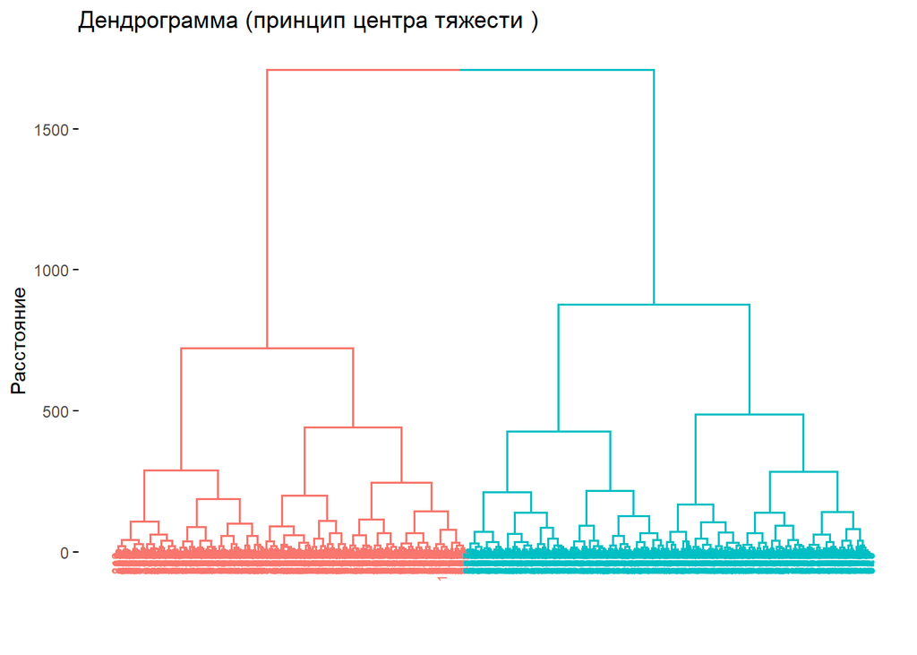

```r
fviz_dend(hclust_ct, cex = 0.5, color_labels_by_k = TRUE,
          main = 'Дендрограмма (принцип центра тяжести )', ylab = 'Расстояние')
```

*Как мы можем заметить, результаты, полученные по методу “центра тяжести” не интерпретабельны*

*Вывод: Исходя из метода “силуэтов”,“статистики разрыва” и метода “локтя” мы пришли к выводу о том, что разбиение будет на 2 кластера, поскольку это оптимально для наших данных и только при этом числе мы получаем наиболее приемлемые результаты. Сравнив результаты, мы можем сделать вывод о том, что наиболее предпочтительным оказался метод “Варда”.*

Примечание: все методы кластеризации описанные выше строились по случайным выборкам размером в 1000 наблюдений. Иначе дендограммы просто не строились из-за C stack limits.

#Использование метода к-средних для классификации объектов

Проведём классификацию с помощью метода k-means, взяв количество центров равное двум.

```r
kmeans3 <- kmeans(cluster_df, centers = 2)
```

```r
kmeans3$centers
```

```
##   Avg..Area.Income Avg..Area.House.Age Avg..Area.Number.of.Rooms
## 1       -0.4644375          -0.3632746                -0.4037803
## 2        0.4567000           0.3572225                 0.3970533
##   Avg..Area.Number.of.Bedrooms Area.Population      Price
## 1                   -0.3368465      -0.2921665 -0.7711085
## 2                    0.3312346       0.2872990  0.7582618
```

#### Проверка гипотезы о равнестве средних значений в кластерах.

Для проверки гипотезы о равенстве средних с помощью anova сначала проверим гипотезу об однородности дисперсий.

```r
df7 <- df1
df7$cluster = kmeans3$cluster
df8 = df7[df7$cluster == 1,]
df9 = df7[df7$cluster == 2,]
z = cluster_df
```

```r
for (i in colnames(df7)[1:5]) {
  print(i)
  print((LeveneTest(df7[[i]], df7$cluster, center = mean))$Pr)
}
```

```
## [1] "Avg..Area.Income"
## [1] 0.4419057        NA
## [1] "Avg..Area.House.Age"
## [1] 0.3700758        NA
## [1] "Avg..Area.Number.of.Rooms"
## [1] 0.1822284        NA
## [1] "Avg..Area.Number.of.Bedrooms"
## [1] 5.231589e-18           NA
## [1] "Area.Population"
## [1] 0.7612021        NA
```

#### Проверим равенство средних:

```r
kruskal.test(list(df8$Avg..Area.Number.of.Rooms, df9$Avg..Area.Number.of.Rooms))
```

```
##
##  Kruskal-Wallis rank sum test
##
## data:  list(df8$Avg..Area.Number.of.Rooms, df9$Avg..Area.Number.of.Rooms)
## Kruskal-Wallis chi-squared = 821.05, df = 1, p-value < 2.2e-16
```

```r
kruskal.test(list(df8$Avg..Area.Number.of.Bedrooms, df9$Avg..Area.Number.of.Bedrooms))
```

```
##
##  Kruskal-Wallis rank sum test
##
## data:  list(df8$Avg..Area.Number.of.Bedrooms, df9$Avg..Area.Number.of.Bedrooms)
## Kruskal-Wallis chi-squared = 509.03, df = 1, p-value < 2.2e-16
```

```r
for (i in colnames(df7)[c(1,2,5)]){
  print(i)
  print(summary(aov(df7[[i]] ~ df7$cluster)))
}
```

```
## [1] "Avg..Area.Income"
## Component 1 :
##               Df     Sum Sq    Mean Sq F value    Pr(>F)
## df7$cluster    1 1.2047e+11 1.2047e+11  1345.9 < 2.2e-16 ***
## Residuals   4998 4.4738e+11 8.9512e+07
## ---
## Signif. codes:  0 '***' 0.001 '**' 0.01 '*' 0.05 '.' 0.1 ' ' 1
##
## [1] "Avg..Area.House.Age"
## Component 1 :
##               Df Sum Sq Mean Sq F value    Pr(>F)
## df7$cluster    1  637.8  637.81  745.48 < 2.2e-16 ***
## Residuals   4998 4276.1    0.86
## ---
## Signif. codes:  0 '***' 0.001 '**' 0.01 '*' 0.05 '.' 0.1 ' ' 1
##
## [1] "Area.Population"
## Component 1 :
##               Df     Sum Sq    Mean Sq F value    Pr(>F)
## df7$cluster    1 4.1348e+10 4.1348e+10  458.07 < 2.2e-16 ***
## Residuals   4998 4.5115e+11 9.0265e+07
## ---
## Signif. codes:  0 '***' 0.001 '**' 0.01 '*' 0.05 '.' 0.1 ' ' 1
```

#### Визуализируем результаты кластеризации через график средних.

По графику средних даем интерпретацию полученным кластерам.

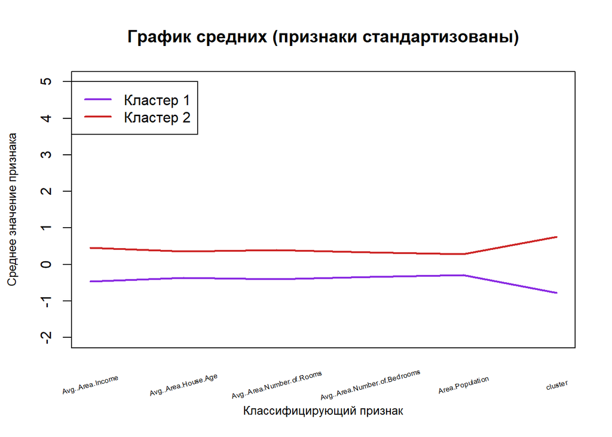

```r
plot(1:ncol(cluster_df), kmeans3$centers[1,], xaxt = 'n', type = 'l', col = 'blueviolet',
     cex.sub = 0.3, cex.lab = 0.8, lwd = 2, ylim = c(-2, 5),
     ylab = 'Среднее значение признака', xlab = 'Классифицирующий признак')

lines(1:ncol(cluster_df), kmeans3$centers[2,], type = 'l', col = 'firebrick3', lwd = 2)



title('График средних (признаки стандартизованы)')
legend(0.8, 5, c('Кластер 1', 'Кластер 2'),
       lwd = c(2, 2), col = c('blueviolet', 'firebrick3'))
text(x =  seq_along(names(df7)), y = par("usr")[3] - 1, srt = 15, adj = 0.5,
     labels = names(df7), xpd = TRUE, cex = 0.5)
```

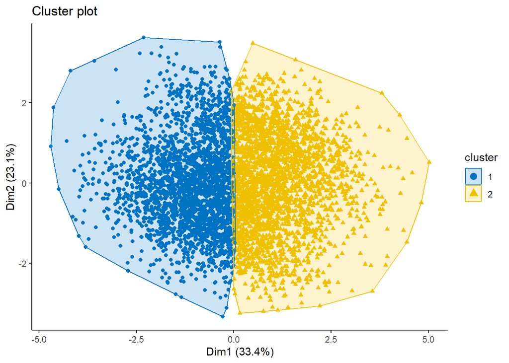

```r
fviz_cluster(kmeans3, cluster_df, geom = "point",
             palette = "jco", ggtheme = theme_classic())
```

C помощью данного графика можно наглядно увидеть, как выглядит распределение кластеров.

#### Вывод: выбранную базу данных можно разбить на два кластера с квартирами большего и меньшего размера. Так как гипотеза о равенстве средних отвергается, то это означает что такое разбиение имеет смысл.

#Построение регрессионных моделей в кластерах

```r
new_df <- subset(data, select = -c(7))
kmeans3 <- kmeans(scale(new_df), centers = 2)
new_df$cl = kmeans3$cluster
df_cl1 = new_df[new_df$cl == 1,-c(7)]
df_cl2 = new_df[new_df$cl == 2,-c(7)]
```

##Регрессионный анализ в кластерах

###Линейный Регрессионный анализ в кластерах

Возьмем переменную Price

```r
lm1 <- lm(Price ~ ., df_cl1)
lm2 <- lm(Price ~., df_cl2)
summary(lm1)
```

```
##
## Call:
## lm(formula = Price ~ ., data = df_cl1)
##
## Residuals:
##     Min      1Q  Median      3Q     Max
## -329943  -67977   -1483   68643  367192
##
## Coefficients:
##                                Estimate Std. Error t value Pr(>|t|)
## (Intercept)                  -2.362e+06  3.611e+04 -65.399   <2e-16 ***
## Avg..Area.Income              2.010e+01  2.374e-01  84.662   <2e-16 ***
## Avg..Area.House.Age           1.520e+05  2.349e+03  64.715   <2e-16 ***
## Avg..Area.Number.of.Rooms     1.090e+05  2.485e+03  43.878   <2e-16 ***
## Avg..Area.Number.of.Bedrooms -1.821e+03  2.051e+03  -0.888    0.375
## Area.Population               1.436e+01  2.290e-01  62.715   <2e-16 ***
## ---
## Signif. codes:  0 '***' 0.001 '**' 0.01 '*' 0.05 '.' 0.1 ' ' 1
##
## Residual standard error: 100400 on 2473 degrees of freedom
## Multiple R-squared:  0.8047, Adjusted R-squared:  0.8043
## F-statistic:  2038 on 5 and 2473 DF,  p-value: < 2.2e-16
```

```r
summary(lm2)
```

```
##
## Call:
## lm(formula = Price ~ ., data = df_cl2)
##
## Residuals:
##     Min      1Q  Median      3Q     Max
## -335492  -67992    1330   67350  318890
##
## Coefficients:
##                                Estimate Std. Error t value Pr(>|t|)
## (Intercept)                  -2.328e+06  4.018e+04 -57.950   <2e-16 ***
## Avg..Area.Income              2.026e+01  2.317e-01  87.455   <2e-16 ***
## Avg..Area.House.Age           1.555e+05  2.332e+03  66.691   <2e-16 ***
## Avg..Area.Number.of.Rooms     1.116e+05  2.445e+03  45.628   <2e-16 ***
## Avg..Area.Number.of.Bedrooms -3.971e+03  1.739e+03  -2.284   0.0225 *
## Area.Population               1.405e+01  2.194e-01  64.055   <2e-16 ***
## ---
## Signif. codes:  0 '***' 0.001 '**' 0.01 '*' 0.05 '.' 0.1 ' ' 1
##
## Residual standard error: 98130 on 2515 degrees of freedom
## Multiple R-squared:  0.8153, Adjusted R-squared:  0.815
## F-statistic:  2221 on 5 and 2515 DF,  p-value: < 2.2e-16
```

Теперь построим модель уже без переменной Avg..Area.Number.of.Bedrooms, чтобы все переменные были значимые

```r
lm1 <- lm(Price ~ Avg..Area.Income + Avg..Area.House.Age + Avg..Area.Number.of.Rooms + Area.Population, df_cl1)
lm2 <- lm(Price ~ Avg..Area.Income + Avg..Area.House.Age + Avg..Area.Number.of.Rooms + Area.Population, df_cl2)

summary(lm1)
```

```
##
## Call:
## lm(formula = Price ~ Avg..Area.Income + Avg..Area.House.Age +
##     Avg..Area.Number.of.Rooms + Area.Population, data = df_cl1)
##
## Residuals:
##     Min      1Q  Median      3Q     Max
## -328737  -68205   -1591   69212  366746
##
## Coefficients:
##                             Estimate Std. Error t value Pr(>|t|)
## (Intercept)               -2.368e+06  3.548e+04  -66.73   <2e-16 ***
## Avg..Area.Income           2.012e+01  2.358e-01   85.35   <2e-16 ***
## Avg..Area.House.Age        1.523e+05  2.329e+03   65.39   <2e-16 ***
## Avg..Area.Number.of.Rooms  1.084e+05  2.372e+03   45.69   <2e-16 ***
## Area.Population            1.438e+01  2.278e-01   63.15   <2e-16 ***
## ---
## Signif. codes:  0 '***' 0.001 '**' 0.01 '*' 0.05 '.' 0.1 ' ' 1
##
## Residual standard error: 100400 on 2474 degrees of freedom
## Multiple R-squared:  0.8047, Adjusted R-squared:  0.8043
## F-statistic:  2548 on 4 and 2474 DF,  p-value: < 2.2e-16
```

```r
summary(lm2)
```

```
##
## Call:
## lm(formula = Price ~ Avg..Area.Income + Avg..Area.House.Age +
##     Avg..Area.Number.of.Rooms + Area.Population, data = df_cl2)
##
## Residuals:
##     Min      1Q  Median      3Q     Max
## -332823  -67846    1425   66383  313390
##
## Coefficients:
##                             Estimate Std. Error t value Pr(>|t|)
## (Intercept)               -2.346e+06  3.948e+04  -59.42   <2e-16 ***
## Avg..Area.Income           2.034e+01  2.295e-01   88.61   <2e-16 ***
## Avg..Area.House.Age        1.561e+05  2.320e+03   67.32   <2e-16 ***
## Avg..Area.Number.of.Rooms  1.099e+05  2.333e+03   47.09   <2e-16 ***
## Area.Population            1.413e+01  2.168e-01   65.20   <2e-16 ***
## ---
## Signif. codes:  0 '***' 0.001 '**' 0.01 '*' 0.05 '.' 0.1 ' ' 1
##
## Residual standard error: 98210 on 2516 degrees of freedom
## Multiple R-squared:  0.8149, Adjusted R-squared:  0.8146
## F-statistic:  2770 on 4 and 2516 DF,  p-value: < 2.2e-16
```

Уравнение для обеих кластеров в целом значимое, поскольку p-value меньше любого разумного уровня значимости.

Проведем тест для проверки неоднородности дисперсии с помощью теста Бройша-Пагана

```r
bptest(lm1)
```

```
##
##  studentized Breusch-Pagan test
##
## data:  lm1
## BP = 16.135, df = 4, p-value = 0.002844
```

```r
bptest(lm2)
```

```
##
##  studentized Breusch-Pagan test
##
## data:  lm2
## BP = 3.3112, df = 4, p-value = 0.5072
```

Так же проведем тест Дарбина-Ватсона, чтобы проверить автокореллированны остатки

```r
durbinWatsonTest(lm1)
```

```
##  lag Autocorrelation D-W Statistic p-value
##    1      0.01568575      1.967926   0.402
##  Alternative hypothesis: rho != 0
```

```r
durbinWatsonTest(lm2)
```

```
##  lag Autocorrelation D-W Statistic p-value
##    1     -0.02670925      2.053388   0.172
##  Alternative hypothesis: rho != 0
```

p-value больше задданого уровня значимости, что говорит о том, что остатки в этой модели не автокоррелированы.

Теперь проверим их остатки на нормальность.

```r
res1 <- lm1$residuals
res2 <- lm2$residuals
pander(shapiro.test(res1))
```

Shapiro-Wilk normality test: `res1`

| Test statistic | P value |
| --- | --- |
| 0.9995 | 0.8361 |

```r
pander(shapiro.test(res2))
```

Shapiro-Wilk normality test: `res2`

| Test statistic | P value |
| --- | --- |
| 0.9991 | 0.2425 |

```r
pander(jarque.bera.test(res2))
```

Jarque Bera Test: `res2`

| Test statistic | df | P value |
| --- | --- | --- |
| 4.855 | 2 | 0.08824 |

```r
pander(jarque.bera.test(res2))
```

Jarque Bera Test: `res2`

| Test statistic | df | P value |
| --- | --- | --- |
| 4.855 | 2 | 0.08824 |

На основе полученных результатов можно сделать вывод о том, что нулевая гипотеза о нормальности распределения остатков не отвергается на уровне значимости $\alpha = 0.05$.

### Проведём нелинейный (степенной) анализ

```r
df_cl1$logP = log(df_cl1$Price)
df_cl2$logP = log(df_cl2$Price)

nlm1 <- lm(logP ~ Avg..Area.Income + Avg..Area.House.Age + Avg..Area.Number.of.Rooms + Avg..Area.Number.of.Bedrooms+Area.Population, df_cl1)
nlm2 <- lm(logP ~ Avg..Area.Income + Avg..Area.House.Age + Avg..Area.Number.of.Rooms + Avg..Area.Number.of.Bedrooms+Area.Population, df_cl2)

pander(summary(nlm1))
```

|  | Estimate | Std. Error | t value | Pr(>\|t\|) |
| --- | --- | --- | --- | --- |
| **(Intercept)** | 9.38 | 0.05686 | 165 | 0 |
| **Avg..Area.Income** | 2.585e-05 | 3.737e-07 | 69.17 | 0 |
| **Avg..Area.House.Age** | 0.1977 | 0.003698 | 53.46 | 0 |
| **Avg..Area.Number.of.Rooms** | 0.146 | 0.003912 | 37.33 | 2.825e-242 |
| **Avg..Area.Number.of.Bedrooms** | 0.007497 | 0.003229 | 2.322 | 0.02034 |
| **Area.Population** | 1.845e-05 | 3.605e-07 | 51.18 | 0 |

Fitting linear model: logP ~ Avg..Area.Income + Avg..Area.House.Age + Avg..Area.Number.of.Rooms + Avg..Area.Number.of.Bedrooms + Area.Population

| Observations | Residual Std. Error | $R^2$ | Adjusted $R^2$ |
| --- | --- | --- | --- |
| 2479 | 0.1581 | 0.7332 | 0.7326 |

```r
pander(summary(nlm2))
```

|  | Estimate | Std. Error | t value | Pr(>\|t\|) |
| --- | --- | --- | --- | --- |
| **(Intercept)** | 11.78 | 0.02735 | 430.6 | 0 |
| **Avg..Area.Income** | 1.299e-05 | 1.577e-07 | 82.38 | 0 |
| **Avg..Area.House.Age** | 0.09977 | 0.001588 | 62.84 | 0 |
| **Avg..Area.Number.of.Rooms** | 0.06998 | 0.001665 | 42.04 | 5.138e-293 |
| **Avg..Area.Number.of.Bedrooms** | -0.005145 | 0.001184 | -4.347 | 1.437e-05 |
| **Area.Population** | 9.047e-06 | 1.494e-07 | 60.57 | 0 |

Fitting linear model: logP ~ Avg..Area.Income + Avg..Area.House.Age + Avg..Area.Number.of.Rooms + Avg..Area.Number.of.Bedrooms + Area.Population

| Observations | Residual Std. Error | $R^2$ | Adjusted $R^2$ |
| --- | --- | --- | --- |
| 2521 | 0.06681 | 0.7983 | 0.7979 |

```r
nlm1 <- lm(logP ~ Avg..Area.Income + Avg..Area.House.Age + Avg..Area.Number.of.Rooms + Area.Population, df_cl1)
nlm2 <- lm(logP ~ Avg..Area.Income + Avg..Area.House.Age + Avg..Area.Number.of.Rooms + Area.Population, df_cl2)

summary(nlm1)
```

```
##
## Call:
## lm(formula = logP ~ Avg..Area.Income + Avg..Area.House.Age +
##     Avg..Area.Number.of.Rooms + Area.Population, data = df_cl1)
##
## Residuals:
##      Min       1Q   Median       3Q      Max
## -2.97799 -0.07289  0.00760  0.09126  0.39481
##
## Coefficients:
##                            Estimate Std. Error t value Pr(>|t|)
## (Intercept)               9.405e+00  5.592e-02  168.19   <2e-16 ***
## Avg..Area.Income          2.575e-05  3.715e-07   69.31   <2e-16 ***
## Avg..Area.House.Age       1.966e-01  3.670e-03   53.56   <2e-16 ***
## Avg..Area.Number.of.Rooms 1.487e-01  3.738e-03   39.79   <2e-16 ***
## Area.Population           1.836e-05  3.589e-07   51.17   <2e-16 ***
## ---
## Signif. codes:  0 '***' 0.001 '**' 0.01 '*' 0.05 '.' 0.1 ' ' 1
##
## Residual standard error: 0.1582 on 2474 degrees of freedom
## Multiple R-squared:  0.7326, Adjusted R-squared:  0.7322
## F-statistic:  1695 on 4 and 2474 DF,  p-value: < 2.2e-16
```

```r
summary(nlm2)
```

```
##
## Call:
## lm(formula = logP ~ Avg..Area.Income + Avg..Area.House.Age +
##     Avg..Area.Number.of.Rooms + Area.Population, data = df_cl2)
##
## Residuals:
##       Min        1Q    Median        3Q       Max
## -0.241461 -0.045208  0.003076  0.044630  0.206749
##
## Coefficients:
##                            Estimate Std. Error t value Pr(>|t|)
## (Intercept)               1.175e+01  2.695e-02  436.15   <2e-16 ***
## Avg..Area.Income          1.309e-05  1.567e-07   83.56   <2e-16 ***
## Avg..Area.House.Age       1.005e-01  1.583e-03   63.50   <2e-16 ***
## Avg..Area.Number.of.Rooms 6.780e-02  1.593e-03   42.57   <2e-16 ***
## Area.Population           9.151e-06  1.480e-07   61.84   <2e-16 ***
## ---
## Signif. codes:  0 '***' 0.001 '**' 0.01 '*' 0.05 '.' 0.1 ' ' 1
##
## Residual standard error: 0.06704 on 2516 degrees of freedom
## Multiple R-squared:  0.7968, Adjusted R-squared:  0.7964
## F-statistic:  2466 on 4 and 2516 DF,  p-value: < 2.2e-16
```

Все коэффициенты оказались значимыми. P-value около F-статистики очень мало, значит уравнение регресси в целом значимо.

Проверим нормальность распределения остатков.

```r
res1 <- nlm1$residuals
res2 <- nlm2$residuals

pander(shapiro.test(res1))
```

Shapiro-Wilk normality test: `res1`

| Test statistic | P value |
| --- | --- |
| 0.7895 | 6.631e-49 * * * |

```r
pander(jarque.bera.test(res1))
```

Jarque Bera Test: `res1`

| Test statistic | df | P value |
| --- | --- | --- |
| 579216 | 2 | 0 * * * |

```r
pander(shapiro.test(res2))
```

Shapiro-Wilk normality test: `res2`

| Test statistic | P value |
| --- | --- |
| 0.9973 | 0.0001976 * * * |

```r
pander(jarque.bera.test(res2))
```

Jarque Bera Test: `res2`

| Test statistic | df | P value |
| --- | --- | --- |
| 17.37 | 2 | 0.0001694 * * * |

Значение p-value крайне мало. Следовательно, гипотеза и нормальности распределения остатков отвергается.

Проведем тест Бреуша-Пагана.

```r
bptest(nlm1)
```

```
##
##  studentized Breusch-Pagan test
##
## data:  nlm1
## BP = 88.484, df = 4, p-value < 2.2e-16
```

```r
bptest(nlm2)
```

```
##
##  studentized Breusch-Pagan test
##
## data:  nlm2
## BP = 50.57, df = 4, p-value = 2.745e-10
```

Значение p-value меньше 0,05, мы можем отвергнуть нулевую гипотезу. Значит в регрессионной модели присутствует гетероскедастичность.

Исходя из отсутствия нормального распределения остатков и присутствия гетероскедастичности данной моделью пользоваться нельзя.

### Построим степенную модель.

```r
ldf1 <- log(df_cl1)
ldf2 <- log(df_cl2)


nlm1 <- lm(Price ~ Avg..Area.Income + Avg..Area.House.Age + Avg..Area.Number.of.Rooms + Avg..Area.Number.of.Bedrooms+Area.Population, ldf1)
nlm2 <- lm(Price ~ Avg..Area.Income + Avg..Area.House.Age + Avg..Area.Number.of.Rooms + Avg..Area.Number.of.Bedrooms+Area.Population, ldf2)

(summary(nlm1))
```

```
##
## Call:
## lm(formula = Price ~ Avg..Area.Income + Avg..Area.House.Age +
##     Avg..Area.Number.of.Rooms + Avg..Area.Number.of.Bedrooms +
##     Area.Population, data = ldf1)
##
## Residuals:
##      Min       1Q   Median       3Q      Max
## -2.92171 -0.07452  0.00469  0.08705  1.87552
##
## Coefficients:
##                               Estimate Std. Error t value Pr(>|t|)
## (Intercept)                  -11.09804    0.34286 -32.369   <2e-16 ***
## Avg..Area.Income               1.49661    0.02378  62.937   <2e-16 ***
## Avg..Area.House.Age            1.00534    0.02106  47.742   <2e-16 ***
## Avg..Area.Number.of.Rooms      0.87492    0.02622  33.370   <2e-16 ***
## Avg..Area.Number.of.Bedrooms   0.01634    0.01210   1.351    0.177
## Area.Population                0.47459    0.01060  44.769   <2e-16 ***
## ---
## Signif. codes:  0 '***' 0.001 '**' 0.01 '*' 0.05 '.' 0.1 ' ' 1
##
## Residual standard error: 0.1683 on 2473 degrees of freedom
## Multiple R-squared:  0.6977, Adjusted R-squared:  0.6971
## F-statistic:  1141 on 5 and 2473 DF,  p-value: < 2.2e-16
```

```r
(summary(nlm2))
```

```
##
## Call:
## lm(formula = Price ~ Avg..Area.Income + Avg..Area.House.Age +
##     Avg..Area.Number.of.Rooms + Avg..Area.Number.of.Bedrooms +
##     Area.Population, data = ldf2)
##
## Residuals:
##      Min       1Q   Median       3Q      Max
## -0.25898 -0.04696  0.00359  0.04979  0.36898
##
## Coefficients:
##                               Estimate Std. Error t value Pr(>|t|)
## (Intercept)                  -1.690173   0.183148  -9.228  < 2e-16 ***
## Avg..Area.Income              0.933327   0.012248  76.202  < 2e-16 ***
## Avg..Area.House.Age           0.616054   0.010532  58.494  < 2e-16 ***
## Avg..Area.Number.of.Rooms     0.502875   0.012944  38.851  < 2e-16 ***
## Avg..Area.Number.of.Bedrooms -0.024057   0.005268  -4.567  5.2e-06 ***
## Area.Population               0.318153   0.005718  55.641  < 2e-16 ***
## ---
## Signif. codes:  0 '***' 0.001 '**' 0.01 '*' 0.05 '.' 0.1 ' ' 1
##
## Residual standard error: 0.07138 on 2515 degrees of freedom
## Multiple R-squared:  0.7697, Adjusted R-squared:  0.7692
## F-statistic:  1681 on 5 and 2515 DF,  p-value: < 2.2e-16
```

```r
nlm1 <- lm(Price ~ Avg..Area.Income + Avg..Area.House.Age + Avg..Area.Number.of.Rooms + Area.Population, ldf1)
nlm2 <- lm(Price ~ Avg..Area.Income + Avg..Area.House.Age + Avg..Area.Number.of.Rooms + Area.Population, ldf2)

summary(nlm1)
```

```
##
## Call:
## lm(formula = Price ~ Avg..Area.Income + Avg..Area.House.Age +
##     Avg..Area.Number.of.Rooms + Area.Population, data = ldf1)
##
## Residuals:
##      Min       1Q   Median       3Q      Max
## -2.92711 -0.07449  0.00418  0.08769  1.86870
##
## Coefficients:
##                            Estimate Std. Error t value Pr(>|t|)
## (Intercept)               -11.03742    0.33997  -32.47   <2e-16 ***
## Avg..Area.Income            1.49304    0.02364   63.17   <2e-16 ***
## Avg..Area.House.Age         1.00191    0.02091   47.92   <2e-16 ***
## Avg..Area.Number.of.Rooms   0.88475    0.02519   35.12   <2e-16 ***
## Area.Population             0.47327    0.01056   44.83   <2e-16 ***
## ---
## Signif. codes:  0 '***' 0.001 '**' 0.01 '*' 0.05 '.' 0.1 ' ' 1
##
## Residual standard error: 0.1683 on 2474 degrees of freedom
## Multiple R-squared:  0.6975, Adjusted R-squared:  0.697
## F-statistic:  1426 on 4 and 2474 DF,  p-value: < 2.2e-16
```

```r
summary(nlm2)
```

```
##
## Call:
## lm(formula = Price ~ Avg..Area.Income + Avg..Area.House.Age +
##     Avg..Area.Number.of.Rooms + Area.Population, data = ldf2)
##
## Residuals:
##      Min       1Q   Median       3Q      Max
## -0.26862 -0.04657  0.00267  0.05044  0.38305
##
## Coefficients:
##                           Estimate Std. Error t value Pr(>|t|)
## (Intercept)               -1.82275    0.18154  -10.04   <2e-16 ***
## Avg..Area.Income           0.94101    0.01218   77.26   <2e-16 ***
## Avg..Area.House.Age        0.62120    0.01051   59.09   <2e-16 ***
## Avg..Area.Number.of.Rooms  0.48413    0.01232   39.28   <2e-16 ***
## Area.Population            0.32194    0.00568   56.68   <2e-16 ***
## ---
## Signif. codes:  0 '***' 0.001 '**' 0.01 '*' 0.05 '.' 0.1 ' ' 1
##
## Residual standard error: 0.07166 on 2516 degrees of freedom
## Multiple R-squared:  0.7678, Adjusted R-squared:  0.7674
## F-statistic:  2080 on 4 and 2516 DF,  p-value: < 2.2e-16
```

Все коэффициенты оказались значимыми. P-value около F-статистики очень мало, значит уравнение регресси в целом значимо.

```r
res1 <- nlm1$residuals
res2 <- nlm2$residuals

pander(shapiro.test(res1))
```

Shapiro-Wilk normality test: `res1`

| Test statistic | P value |
| --- | --- |
| 0.793 | 1.258e-48 * * * |

```r
pander(jarque.bera.test(res1))
```

Jarque Bera Test: `res1`

| Test statistic | df | P value |
| --- | --- | --- |
| 382398 | 2 | 0 * * * |

```r
pander(shapiro.test(res2))
```

Shapiro-Wilk normality test: `res2`

| Test statistic | P value |
| --- | --- |
| 0.9964 | 9.43e-06 * * * |

```r
pander(jarque.bera.test(res2))
```

Jarque Bera Test: `res2`

| Test statistic | df | P value |
| --- | --- | --- |
| 20.22 | 2 | 4.06e-05 * * * |

```r
cluster_df <- as.data.frame(scale(new_df))
```

Значение p-value крайне мало. Следовательно, гипотеза и нормальности распределения остатков отвергается.

Проведем тест Бреуша-Пагана.

```r
bptest(nlm1)
```

```
##
##  studentized Breusch-Pagan test
##
## data:  nlm1
## BP = 173.44, df = 4, p-value < 2.2e-16
```

```r
bptest(nlm2)
```

```
##
##  studentized Breusch-Pagan test
##
## data:  nlm2
## BP = 96.07, df = 4, p-value < 2.2e-16
```

Значение p-value меньше 0,05, мы можем отвергнуть нулевую гипотезу. Значит в регрессионной модели присутствует гетероскедастичность.

Исходя из отсутствия нормального распределения остатков и присутствия гетероскедастичности данной моделью пользоваться нельзя.

Обе нелинейные модели оказались нерабочими из-за невыполнения предпосылок регрессионного анализа: 1) нормальность остатков 2) отсутствие гетероскедастичности

Поэтому будем использовать линейные модели `lm1` и `lm2`.

## Интерпретация коэффициентов регрессии в кластерах.

Произведём расчёт коэффициентов эластичности для модели `lm1`.

```r
for (i in 1:4){
  if (i== 4) k=i+1 else k=i
print(lm1$coefficients[i+1]*mean(df_cl1[[k]])/mean(df_cl1$Price))
}
```

```
## Avg..Area.Income
##          1.33414
## Avg..Area.House.Age
##            0.891191
## Avg..Area.Number.of.Rooms
##                 0.7432239
## Area.Population
##        0.498495
```

Произведём расчёт коэффициентов эластичности для модели `lm2`.

```r
for (i in 1:4){
  if (i== 4) k=i+1 else k=i
print(lm2$coefficients[i+1]*mean(df_cl1[[k]])/mean(df_cl1$Price))
}
```

```
## Avg..Area.Income
##         1.348335
## Avg..Area.House.Age
##           0.9138025
## Avg..Area.Number.of.Rooms
##                 0.7535033
## Area.Population
##       0.4898715
```

Как можно видеть, значения коэффициентов эластичности отличаются не очень сильно.

## Сравнение с моделью построенной с моделью построенной на всю совокупность объектов.

Наша модель на всю совокупность объектов выглядит следующим образом:

```r
lm <- lm(Price ~ Avg..Area.Income + Avg..Area.House.Age + Avg..Area.Number.of.Rooms + Area.Population, new_df)
pander(summary(lm))
```

|  | Estimate | Std. Error | t value | Pr(>\|t\|) |
| --- | --- | --- | --- | --- |
| **(Intercept)** | -2637561 | 17158 | -153.7 | 0 |
| **Avg..Area.Income** | 21.58 | 0.1343 | 160.7 | 0 |
| **Avg..Area.House.Age** | 165658 | 1443 | 114.8 | 0 |
| **Avg..Area.Number.of.Rooms** | 121598 | 1423 | 85.48 | 0 |
| **Area.Population** | 15.2 | 0.1442 | 105.4 | 0 |

Fitting linear model: Price ~ Avg..Area.Income + Avg..Area.House.Age + Avg..Area.Number.of.Rooms + Area.Population

| Observations | Residual Std. Error | $R^2$ | Adjusted $R^2$ |
| --- | --- | --- | --- |
| 5000 | 101159 | 0.918 | 0.9179 |

Теперь посмотрим на модели в кластерах.

```r
pander(summary(lm1))
```

|  | Estimate | Std. Error | t value | Pr(>\|t\|) |
| --- | --- | --- | --- | --- |
| **(Intercept)** | -2367826 | 35484 | -66.73 | 0 |
| **Avg..Area.Income** | 20.12 | 0.2358 | 85.35 | 0 |
| **Avg..Area.House.Age** | 152277 | 2329 | 65.39 | 0 |
| **Avg..Area.Number.of.Rooms** | 108382 | 2372 | 45.68 | 0 |
| **Area.Population** | 14.38 | 0.2278 | 63.15 | 0 |

Fitting linear model: Price ~ Avg..Area.Income + Avg..Area.House.Age + Avg..Area.Number.of.Rooms + Area.Population

| Observations | Residual Std. Error | $R^2$ | Adjusted $R^2$ |
| --- | --- | --- | --- |
| 2479 | 100395 | 0.8047 | 0.8043 |

```r
pander(summary(lm2))
```

|  | Estimate | Std. Error | t value | Pr(>\|t\|) |
| --- | --- | --- | --- | --- |
| **(Intercept)** | -2345696 | 39478 | -59.42 | 0 |
| **Avg..Area.Income** | 20.34 | 0.2295 | 88.61 | 0 |
| **Avg..Area.House.Age** | 156141 | 2320 | 67.32 | 0 |
| **Avg..Area.Number.of.Rooms** | 109881 | 2333 | 47.09 | 0 |
| **Area.Population** | 14.13 | 0.2168 | 65.2 | 0 |

Fitting linear model: Price ~ Avg..Area.Income + Avg..Area.House.Age + Avg..Area.Number.of.Rooms + Area.Population

| Observations | Residual Std. Error | $R^2$ | Adjusted $R^2$ |
| --- | --- | --- | --- |
| 2521 | 98214 | 0.8149 | 0.8146 |

Теперь обратимся к информационным критериям:

```r
IC_table <- data.frame(n = c('lm', 'lm1', 'lm2'),
                  a = rbind(AIC(lm), AIC(lm1), AIC(lm2)),
                  b = rbind(BIC(lm), BIC(lm1), BIC(lm2)))
# информационный критерий Акаике
kbl(IC_table,
    caption = "Таблица 1. Информационные критерии Акаике и Шварца (Баесовский инф. критерий)",
    booktabs = T, col.names = c("Модель", "Значение AIC", "Значение BIC")) %>%
    kable_classic(html_font = "Cambria", font_size = 12, full_width = F)
```

Таблица 1. Информационные критерии Акаике и Шварца (Баесовский инф. критерий)

| Модель | Значение AIC | Значение BIC |
| --- | --- | --- |
| lm | 129440.91 | 129480.01 |
| lm1 | 64142.74 | 64177.63 |
| lm2 | 65118.58 | 65153.58 |

Вывод: Лучше использовать регрессионные модели по кластерам, чем по всей выборке, поскольку значение информационных критериев для моделей по кластерам ниже.

## Дискриминантный анализ

Стоит напомнить о предпосылках ДА.

Во первых, должна присутствовать слабая корреляция между переменными, в прошлом пункте, мы избавились от сильнокоррелирующих переменных.

Во вторых, должна быть нормальность распределения переменных, в прошлой работе мы доказали, что наше распределение подчиняется нормальному закону распределения

В третьих, должна соблюдаться однородность дисперсий в группах, к сожалению по нашим данным это условие не соблюдается

### Построение дискриминантной функции

Построим дискриминантную функцию без учета последних 4 наблюдений, чтобы проверить в конце, адекватно ли работает наша модель предсказания

Создаем новый датафрейм без 4 наблюдений

```r
da_df = data_scaled[-c(4997:5000),-c(6)]
new_obs = data_scaled[c(4997:5000),-c(6)]
```

```r
cluster_df1 <- as.data.frame(da_df)
```

Проводим кластеризацию методом k-means для новых данных

```r
kmeans4 <- kmeans(da_df, centers = 2)
```

```r
cl <- kmeans4$cluster
da_df$cluster = cl
```

```r
kmeans4$centers
```

```
##   Avg..Area.Income Avg..Area.House.Age Avg..Area.Number.of.Rooms
## 1      0.004083662        -0.003066321                -0.6738844
## 2     -0.005193064         0.003013188                 0.8507119
##   Avg..Area.Number.of.Bedrooms Area.Population
## 1                   -0.6080044     -0.02427065
## 2                    0.7665680      0.03044345
```

Разделим выборку на обучающую (2/3) и тестовую (1/3)

```r
smpl_size <- floor(2/3 * nrow(da_df))

set.seed(1337)
train_ind <- sample(seq_len(nrow(da_df)), size = smpl_size)

data.train <- as.data.frame(da_df[train_ind,])
data.unknown <- as.data.frame(da_df[-train_ind,])
```

### Построение дискриминантной функции.

```r
lda.fit <- lda(data.train[,-c(6)], data.train$cl)
lda.fit
```

```
## Call:
## lda(data.train[, -c(6)], data.train$cl)
##
## Prior probabilities of groups:
##         1         2
## 0.5516517 0.4483483
##
## Group means:
##   Avg..Area.Income Avg..Area.House.Age Avg..Area.Number.of.Rooms
## 1     -0.004974786        -0.003600616                -0.6734439
## 2     -0.019487034        -0.003915198                 0.8389006
##   Avg..Area.Number.of.Bedrooms Area.Population
## 1                   -0.6068753     -0.02837010
## 2                    0.7836754      0.04854403
##
## Coefficients of linear discriminants:
##                                        LD1
## Avg..Area.Income             -0.0128445109
## Avg..Area.House.Age           0.0009764665
## Avg..Area.Number.of.Rooms     1.2307625117
## Avg..Area.Number.of.Bedrooms  0.9419792447
## Area.Population               0.0850858449
```

уравнение LD1 ,будет выглядеть следующим образом

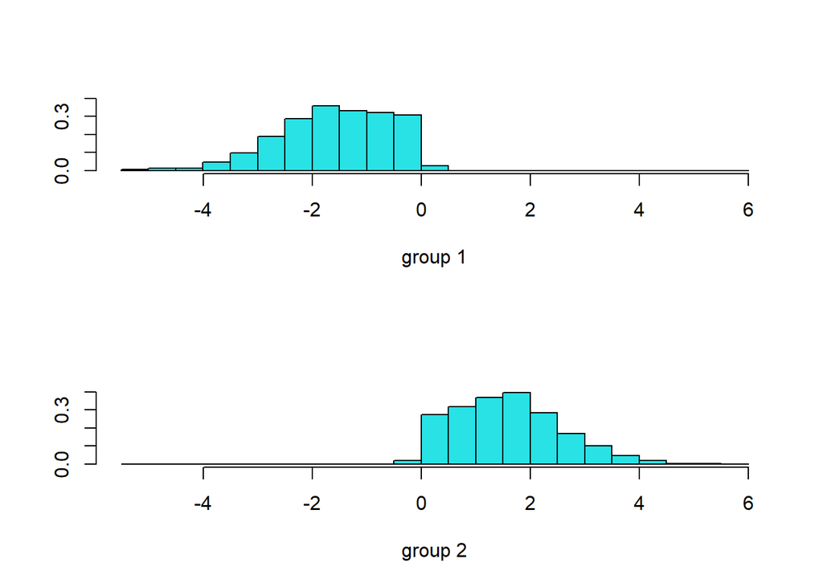

```r
plot(lda.fit)
```

Как мы видим, разделение прошло хорошо, данные равномерно распределились

Теперь проведем предсказание класса с помощью дискриминантной функции

Прогноз для наблюдений из тестовой выборки: “class” содержит информацию о предсказанной группе для каждого наблюдения “posterior” – матрица вероятности принадлежности к каждому классу для каждого наблюдения из тестовой выборки “x” - значение дискриминантной функции

```r
lda.pred <- predict(lda.fit, data.unknown[,-c(6)])
names(lda.pred)
```

```
## [1] "class"     "posterior" "x"
```

Гистограмма значений первой дискриминантной функции:

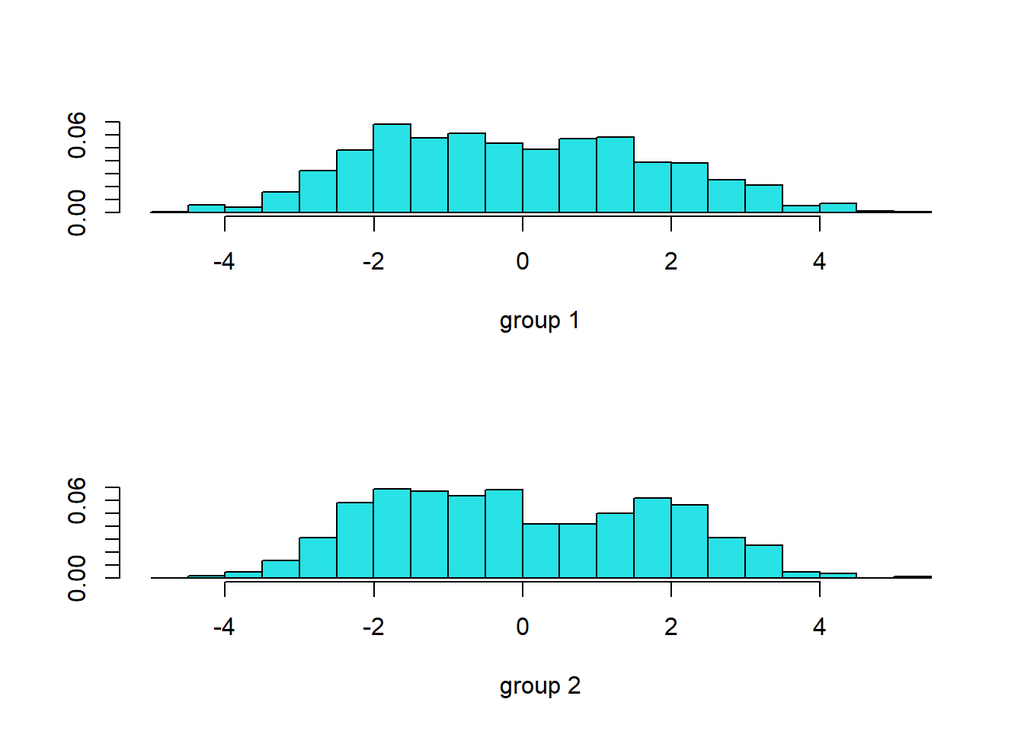

```r
ldahist(data = lda.pred$x[,1], g = cl)
```

Значения накладываются друг на друга

```r
misclass <- function(pred, obs) { tbl <- table(pred, obs)
sum <- colSums(tbl)
dia <- diag(tbl)
msc <- ((sum - dia)/sum) * 100
m.m <- mean(msc)
cat("Classification table:", "\n")
print(tbl)
cat("Misclassification errors:", "\n")
print(round(msc, 2))

print(round(m.m, 2))}

misclass(lda.pred$class, data.unknown[,c("cluster")])
```

```
## Classification table:
##     obs
## pred   1   2
##    1 944  10
##    2   5 707
## Misclassification errors:
##    1    2
## 0.53 1.39
## [1] 0.96
```

Как мы видим, ошибка предсказания в данной модели составляет 0,96 %, это очень хороший результат, он показывает, что дискриминантная модель качественная. Так же можно увидеть ошибки предсказания для отдельных классов, 1,39 и 0,53 провенцтов соотвественно, что равняется 10 и 5 соответвенно, это значит, что какие-то 15 значений попали в неправильный класс, но из общей выборки это составляет всего 1 процент, поэтому это ошибка является незначительной.

Построение лямбды Уилкса

```r
ldam <- manova(as.matrix(data.unknown[,-c(6)]) ~ lda.pred$class)

summary(ldam, test = "Wilks")
```

```
##                  Df   Wilks approx F num Df den Df    Pr(>F)
## lda.pred$class    1 0.28093   849.77      5   1660 < 2.2e-16 ***
## Residuals      1664
## ---
## Signif. codes:  0 '***' 0.001 '**' 0.01 '*' 0.05 '.' 0.1 ' ' 1
```

Значение лямбды Уилкса равно 0.28, нельзя сказать, что это идеальное значение, но это значение говорит о том, что дискриминантная функция получилась качественной

Набор переменных имеется значительное влияние на разбиение на классы.

Далее добавим 4 наблюдения, которые удалили в конце и посмотрим, хорошо ли наша модель предсказывает классы наблюдений

```r
predict(kmeans4, new_obs[,-c(6)])
```

```
## [1] 1 1 2 1
```

```r
predict(lda.fit, new_obs[,-c(6)])
```

```
## $class
## [1] 1 1 2 1
## Levels: 1 2
##
## $posterior
##               1            2
## 4997 0.93247726 6.752274e-02
## 4998 0.99999902 9.834995e-07
## 4999 0.03018231 9.698177e-01
## 5000 0.74083179 2.591682e-01
##
## $x
##             LD1
## 4997 -0.5967359
## 4998 -4.1231641
## 4999  1.3212479
## 5000 -0.1011050
```

Как мы видим, модель идеально предсказала все классы наблюдений, что говорит о высоком качестве модели.